# Лабораторная работа №5

Сеть Петри

Софич Андрей Геннадьевич

safich05@mail.ru

Российский университет дружбы народов

2026-18-04

## Докладчик

- Софич Андрей Геннадьевич

## Актуальность

Изучить и применить метод сетей Петри на задаче голодных философов

## Цели и задачи

Применить сеть Петри на базовой задаче.

## Выполнение лабораторной работы

Создаем рабочий каталог и инициализируем проект в julia .

[figure not shown]

Инициализация проекта

Создаем файл, где прописываем пакеты, необходимые для выполнения работы и запускаем его.

[figure not shown]

Подключение необходимых пакетов

Создаем файл в папке scr, в котором мы пропишем методы моделирования, позиции, переходы и обнаружение deadlock.

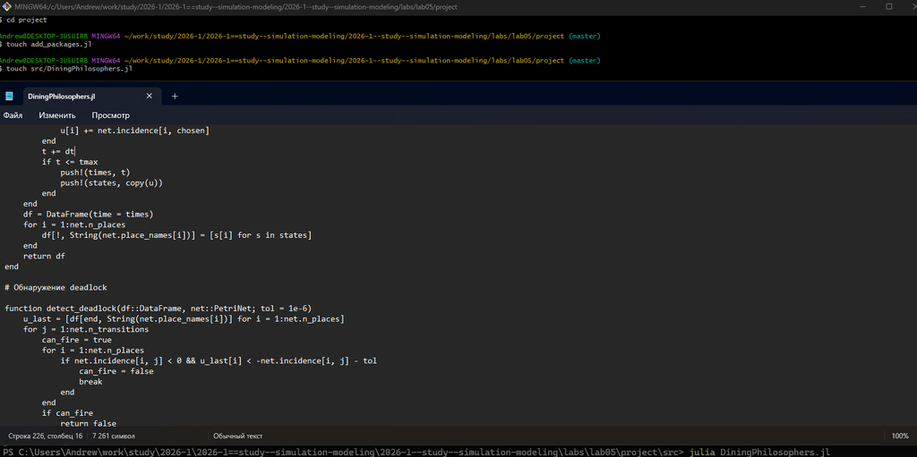

Создание файла для базовых определений

Создаем и запускаем скрипт,который проводит базовый экперимент для сравнения двух вариантов сети Петри.

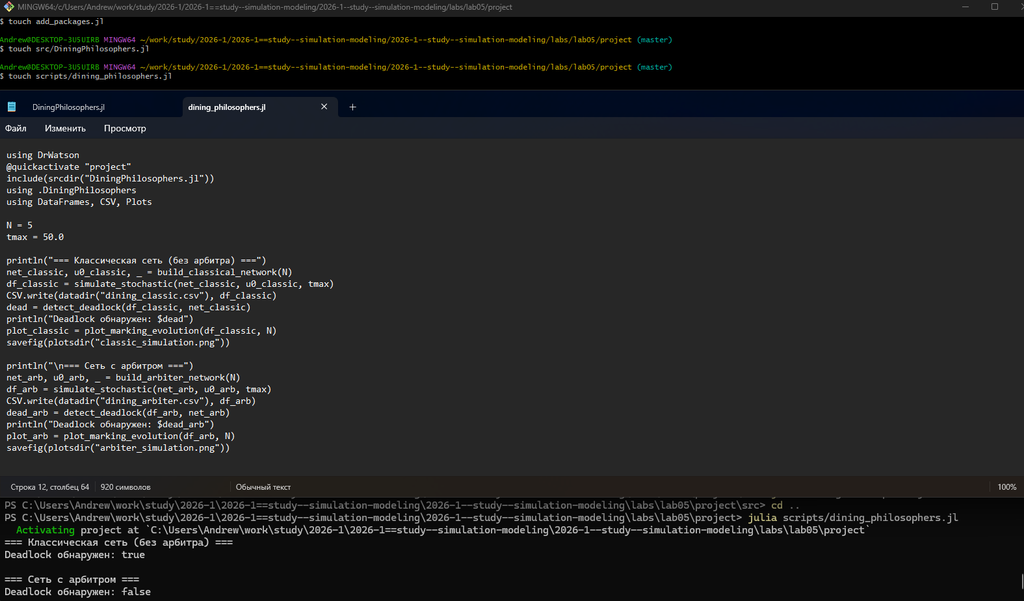

Базовый эксперимент

Получаем результатфы эксперимента для разных вариантов и проводим анализ: модель с арбитром может работаь без блокировки, тогда как классическая рано или поздно придет к deadlock.

[figure not shown]

Результаты базового эксперимента

Преобразовываем код в произвольные стили, открываем jupyter файл и убеждаемся в правильной компиляции.

[figure not shown]

Код из jupyter notebook

Прописываем скрипт, который создаст наглядную анимацию эксперимента в виде gif, она позволит увидеть как меняется маркировка в каждой позиции и покажет возникновение deadlock.

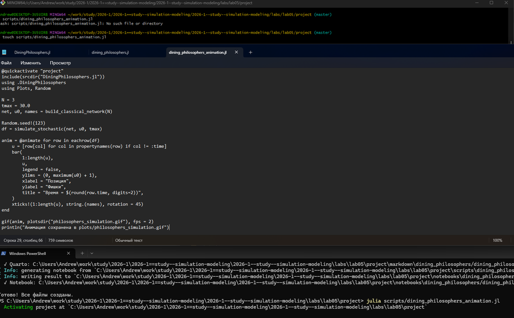

Файл с анимацией эксперимента

В результате получаем анимацию модели, на ней наглядно видно, что в классической модели произойдет взаимная блокировка.

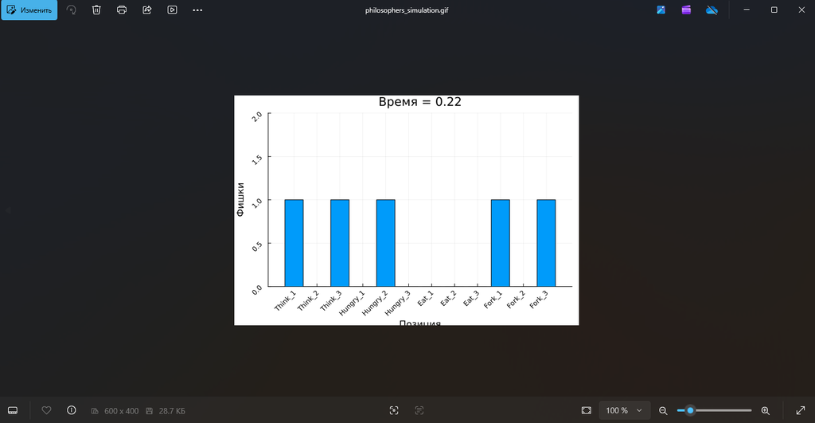

Анимация экперимента

Создаем скрипт с итоговым отчетом, который покажет полный график по каждой модели на основе базового эксперимента, запускаем его и анализируем график.

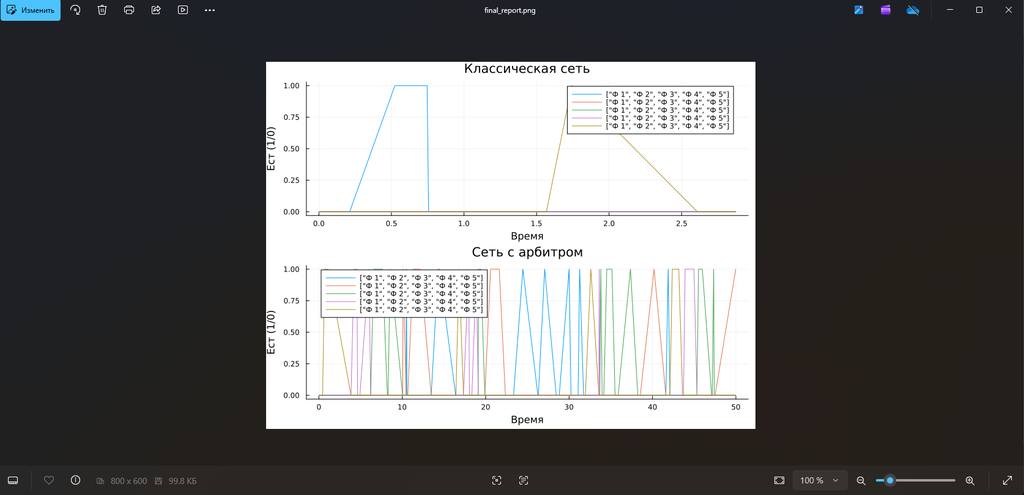

Итоговый отчет

Преобразовываем код в произвольные стили, открываем jupyter файл и убеждаемся в правильной компиляции.

[figure not shown]

Код из jupyter notebook

## Выводы

В данной работе мы изучили и применили сеть Петри на основе базовой задачи про голодных философов.